# Chapter 5

Bryan Li

2/7/2019

#### 2)

1. Range: 7.45 - 4.15 = **3.3** / IQR: 6.2 - 5.6 = **0.6**
2. The distribution of the weights is skewed as the mean weight is 6 pounds whereas the median weight is 6.55 pounds on a range of 3.3. It would be **skewed towards the left.**
3. All values would be **multiplied by 16.** The range would be 52.8; the mean, 96; the median 104.8; the first and third quartiles 89.6 and 99.2; the standard deviation 10.4, and the IQR 9.6.
4. The mean would be **126** (ounces), the first and third quartiles **119.6** and **129.2**, and the mean **134.8**. The IQR, standard deviation, and range would **remain the same**.
5. The **median, IQR, and quartiles** may not change.

#### 17)

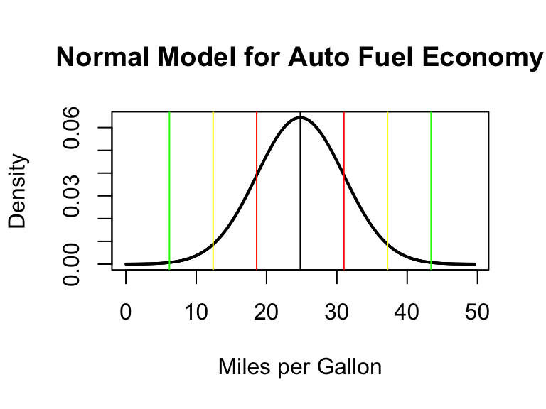

The center line above shows the center of the normal distribution. The two red lines denote the boundaries (of mpg) of the area which contains approximately 68% of the population. Similarly, the yellow lines denote the area that contains 95%, and the green lines 99.7%.

2. I would expect the central 68% of autos to be found from **18.6** to **31**.
3. Approximately **15.8655254%** of autos should get more than 31 mpg.
4. Approximately **13.4106385%** of autos should get between 31 and 37 mpg.
5. The gas mileage of the worst 2.5% of all cars is at **12.6482233** or lower mpg.

#### 33)

1. **12.1672505%** of steers weigh over 1250 pounds.
2. **71.6145417%** of steers weigh under 1200 pounds.
3. **23.2757662%** of steers weigh between 1000 and 1100 pounds.

#### 35)

1. The cutoff for the highest 10% of weights is **1259.6503315 pounds**.
2. The cutoff for the lowest 20% of weights is **1081.3038164 pounds**.
3. The cutoffs for the middle 40% of weights are **1107.9503569 pounds** and **1196.0496431 pounds**.

#### 50)

1. The standard deviation of the weights of Romas being grown is **3.2612379**.
2. The target mean should be **75.7094038**.
3. The standard deviation of the weights of these new Romas is **2.8560232**.
4. The original variety of Roma tomatoes have a wider spread regarding their size, whereas the new variety has a lesser spread. Both varieties have a symmetric shape and approximately equal centers.